# Homework 5

Ryan Hensley

2023-10-06

**Copyright Kaitlyn Hoffmann, All rights reserved. Not for resale, distribution, or posting to external sites for all content provided.**

# Data, Plots, Correlation Coefficient

Data taken from: https://www.kaggle.com/datasets/kumarajarshi/life-expectancy-who/data

## Read the data from LifeExpectancyData.csv creating a new data frame called life

```r
life = read.csv("LifeExpectancyData.csv")
```

## Display the top 10 rows of the data in life data frame

```r
head(life,10)
```

```
##        Country Year     Status LifeExpectancy AdultMortality InfantDeaths
## 1  Afghanistan 2015 Developing           65.0            263           62
## 2  Afghanistan 2014 Developing           59.9            271           64
## 3  Afghanistan 2013 Developing           59.9            268           66
## 4  Afghanistan 2012 Developing           59.5            272           69
## 5  Afghanistan 2011 Developing           59.2            275           71
## 6  Afghanistan 2010 Developing           58.8            279           74
## 7  Afghanistan 2009 Developing           58.6            281           77
## 8  Afghanistan 2008 Developing           58.1            287           80
## 9  Afghanistan 2007 Developing           57.5            295           82
## 10 Afghanistan 2006 Developing           57.3            295           84
##    Alcohol Perct_Expenditure HepatitisB Measles  BMI Polio TotalExpenditure
## 1     0.01         71.279624         65    1154 19.1     6             8.16
## 2     0.01         73.523582         62     492 18.6    58             8.18
## 3     0.01         73.219243         64     430 18.1    62             8.13
```

[output cut: 18 more lines]

## Display the column names in life data frame

```r
colnames(life)
```

```
##  [1] "Country"           "Year"              "Status"
##  [4] "LifeExpectancy"    "AdultMortality"    "InfantDeaths"
##  [7] "Alcohol"           "Perct_Expenditure" "HepatitisB"
## [10] "Measles"           "BMI"               "Polio"
## [13] "TotalExpenditure"  "Diphtheria"        "HIV_AIDS"
## [16] "GDP"               "Population"        "IncomeComp"
## [19] "Schooling"
```

## Plot the following: par(mfrow=c(1,2))

- 1. Plot of LifeExpectancy vs AdultMortality (LifeExpectancy should be on Y axis) (x,y) | col = “grey” | main=“Life Expectancy and Adult Mortality”
- abline(lm(LifeExpectancy~AdultMortality, data=life),lwd = 2, col=“red”)
- 2. Plot of LifeExpectancy vs BMI (LifeExpectancy should be on Y axis) (x,y) | col = “grey” | main=“Life Expectancy and BMI”
- abline(lm(LifeExpectancy~BMI, data=life),lwd = 2, col=“darkgreen”)

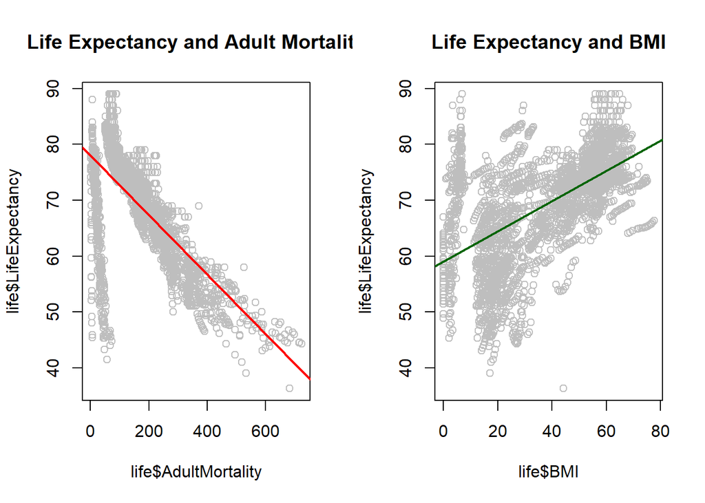

```r
par(mfrow=c(1,2))
plot(life$AdultMortality,life$LifeExpectancy,main="Life Expectancy and Adult Mortality",col="grey")
abline(lm(LifeExpectancy~AdultMortality, data=life),lwd = 2, col="red")
plot(life$BMI,life$LifeExpectancy,main="Life Expectancy and BMI",col="grey")
abline(lm(LifeExpectancy~BMI, data=life),lwd = 2, col="darkgreen")
```

## Display the following 9 plots in 3 rows and 3 columns (the code all must go in the same chunk—each on a new line): par (mfrow=c(3,3))

- 1. LifeExpectancy vs AdultMortality main=“Life Expectancy and Adult Mortality”
- 2. LifeExpectancy vs InfantDeaths main=“Life Expectancy and InfantDeaths”
- 3. LifeExpectancy vs Alcohol main=“Life Expectancy and Alcohol”
- 4. LifeExpectancy vs Perct_Expenditure main=“Life Expectancy and Perct_Expenditure”
- 5. LifeExpectancy vs HepatitisB main=“Life Expectancy and HepatitisB”
- 6. LifeExpectancy vs Measles main=“Life Expectancy and Measles”
- 7. LifeExpectancy vs BMI main=“Life Expectancy and BMI”
- 8. LifeExpectancy vs Polio main=“Life Expectancy and Polio”
- 1. LifeExpectancy vs TotalExpenditure main=“Life Expectancy and TotalExpenditure”
- Add a linear regression line to each plot for bullet points a through i above. abline(lm(dependent~independent, data=life), lwd=2, col=“red”)
- Determine whether each independent variable has a positive or negative relationship with LifeExpectancy. Answer Negative and Positive within the chunk (comment)

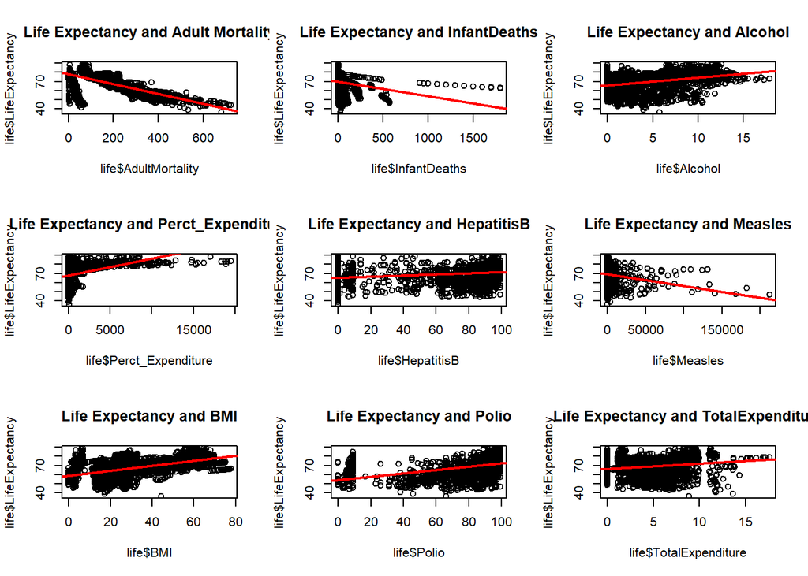

```r
par (mfrow=c(3,3))
  plot(life$AdultMortality,life$LifeExpectancy,main="Life Expectancy and Adult Mortality")
  abline(lm(LifeExpectancy~AdultMortality, data=life), lwd=2, col="red")

  plot(life$InfantDeaths,life$LifeExpectancy,main="Life Expectancy and InfantDeaths")
  abline(lm(LifeExpectancy~InfantDeaths, data=life), lwd=2, col="red")

  plot(life$Alcohol,life$LifeExpectancy,main="Life Expectancy and Alcohol")
  abline(lm(LifeExpectancy~Alcohol, data=life), lwd=2, col="red")

  plot(life$Perct_Expenditure,life$LifeExpectancy,main="Life Expectancy and Perct_Expenditure")
  abline(lm(LifeExpectancy~Perct_Expenditure, data=life), lwd=2, col="red")

  plot(life$HepatitisB,life$LifeExpectancy,main="Life Expectancy and HepatitisB")
  abline(lm(LifeExpectancy~HepatitisB, data=life), lwd=2, col="red")

  plot(life$Measles,life$LifeExpectancy,main="Life Expectancy and Measles")
  abline(lm(LifeExpectancy~Measles, data=life), lwd=2, col="red")

  plot(life$BMI,life$LifeExpectancy,main="Life Expectancy and BMI")
  abline(lm(LifeExpectancy~BMI, data=life), lwd=2, col="red")

  plot(life$Polio,life$LifeExpectancy,main="Life Expectancy and Polio")
  abline(lm(LifeExpectancy~Polio, data=life), lwd=2, col="red")

  plot(life$TotalExpenditure,life$LifeExpectancy,main="Life Expectancy and TotalExpenditure")
  abline(lm(LifeExpectancy~TotalExpenditure, data=life), lwd=2, col="red")
```

```r
#Positive Relationship: Alcohol, Perct_Expenditure,HepetitisB,BMI,Polio,TotalExpenditure
#Negative Relationship:AdultMortality,InfantDeaths,Measles
```